# A03_G34801183

Bisman Sachar

February 2, 2019

Downloading data directly from the AWS link to the R mardown file and saving it in fkicks dataframe object

```r
fkicks <- read.table("https://s3.amazonaws.com/programmingforanalytics/footballkicks.csv", header = TRUE, sep = ",")
```

# PART A - Predicting Melvin’s attemps at field goals using simple probabilities

### Analyzing the data using str() and summary()

```r
str(fkicks)
```

```
## 'data.frame':    952 obs. of  3 variables:
##  $ yards          : int  18 19 19 19 19 19 20 20 20 20 ...
##  $ goal           : Factor w/ 2 levels "N","Y": 2 2 2 2 2 2 1 2 2 2 ...
##  $ practiceormatch: Factor w/ 2 levels "M","P": 2 2 2 2 2 2 2 2 2 2 ...
```

```r
summary(fkicks)
```

```
##      yards      goal    practiceormatch
##  Min.   :18.0   N:193   M: 90
##  1st Qu.:28.0   Y:759   P:862
##  Median :37.0
##  Mean   :36.5
##  3rd Qu.:45.0
##  Max.   :62.0
```

It tells us that overall, Melvin scored 79.72% (759 out of 952 kicks) of the times he attempted. He played 90 matches & 862 practice matches. He attempted from 18 to 62 yards. yards is a continuous variable, goal is a discrete and categorical variable, practiceormatch is discrete & categorical variable

### Checking confusion matrix at Melvin’s attempts using prop.table().

```r
prop.table(table(fkicks$goal, fkicks$yards))
```

```
##
##              18          19          20          21          22
##   N 0.000000000 0.000000000 0.001050420 0.001050420 0.000000000
##   Y 0.001050420 0.005252101 0.018907563 0.017857143 0.037815126
##
##              23          24          25          26          27
##   N 0.000000000 0.002100840 0.000000000 0.001050420 0.000000000
##   Y 0.034663866 0.029411765 0.017857143 0.027310924 0.033613445
##
##              28          29          30          31          32
##   N 0.001050420 0.004201681 0.003151261 0.003151261 0.002100840
##   Y 0.032563025 0.034663866 0.019957983 0.024159664 0.016806723
##
##              33          34          35          36          37
##   N 0.003151261 0.006302521 0.007352941 0.004201681 0.007352941
##   Y 0.032563025 0.019957983 0.021008403 0.022058824 0.029411765
##
##              38          39          40          41          42
##   N 0.007352941 0.007352941 0.005252101 0.010504202 0.002100840
##   Y 0.027310924 0.027310924 0.025210084 0.023109244 0.027310924
##
##              43          44          45          46          47
##   N 0.007352941 0.011554622 0.008403361 0.009453782 0.007352941
##   Y 0.022058824 0.021008403 0.013655462 0.026260504 0.021008403
##
##              48          49          50          51          52
##   N 0.015756303 0.013655462 0.011554622 0.006302521 0.009453782
##   Y 0.022058824 0.016806723 0.014705882 0.012605042 0.005252101
##
##              53          54          55          56          57
##   N 0.007352941 0.005252101 0.005252101 0.000000000 0.001050420
##   Y 0.007352941 0.003151261 0.001050420 0.001050420 0.001050420
##
##              58          60          62
##   N 0.000000000 0.002100840 0.001050420
##   Y 0.001050420 0.000000000 0.000000000
```

```r
prop.table(table(fkicks$goal, fkicks$practiceormatch))
```

```
##
##              M          P
##   N 0.01680672 0.18592437
##   Y 0.07773109 0.71953782
```

### To get probabilities, we need to convert goal non-numeric levels into numeric levels

```r
fkicks$goal <- ifelse(fkicks$goal == "Y", 1,0)
```

### Calculating goal success rate differentiated by practice or match

```r
library(dplyr)
fkicks %>% summarise(avggoal = mean(fkicks$goal))
```

```
##     avggoal
## 1 0.7972689
```

#### Melvin’s overall success rate is 79.72%

```r
fkicks %>% group_by(practiceormatch) %>% summarise(avggoal = mean(goal))
```

```
## # A tibble: 2 x 2
##   practiceormatch avggoal
##   <fct>             <dbl>
## 1 M                 0.822
## 2 P                 0.795
```

#### Melvin’s goal success rate in matches is 82.2%. Melvin’s goal success rate in practice is 79.5%.

# PART B - Predicting probabilites using logistic function.

### i)Writing logistic function for practice

### Creating a subset of data with only Practice (P)

```r
fkicks1 <- fkicks %>% filter(practiceormatch=="P")
```

### Running logistic function and finding intercept values

```r
goalp.log = glm(goal ~ yards,
                  data = fkicks1,
                  family=binomial)
summary(goalp.log)
```

```
##
## Call:
## glm(formula = goal ~ yards, family = binomial, data = fkicks1)
##
## Deviance Residuals:
##     Min       1Q   Median       3Q      Max
## -2.6690   0.2538   0.3950   0.7057   1.4702
##
## Coefficients:
##             Estimate Std. Error z value Pr(>|z|)
## (Intercept)  5.80284    0.47356   12.25   <2e-16 ***
## yards       -0.11349    0.01115  -10.18   <2e-16 ***
## ---
## Signif. codes:  0 '***' 0.001 '**' 0.01 '*' 0.05 '.' 0.1 ' ' 1
##
## (Dispersion parameter for binomial family taken to be 1)
##
##     Null deviance: 875.30  on 861  degrees of freedom
## Residual deviance: 741.28  on 860  degrees of freedom
## AIC: 745.28
##
## Number of Fisher Scoring iterations: 5
```

#### This gives us the logit function - ln(p/1-p) = 5.802 - 0.113 * yards, where p is the probability of goal

### ii) Writing logistic function for matches

### Creating a subset of data with only Match (M)

```r
fkicks2 <- fkicks %>% filter(practiceormatch=="M")
```

### Running logistic function and finding intercept values

```r
goalm.log = glm(goal ~ yards,
                  data = fkicks2,
                  family=binomial)
summary(goalm.log)
```

```
##
## Call:
## glm(formula = goal ~ yards, family = binomial, data = fkicks2)
##
## Deviance Residuals:
##     Min       1Q   Median       3Q      Max
## -2.4254   0.3293   0.4865   0.6999   1.1253
##
## Coefficients:
##             Estimate Std. Error z value Pr(>|z|)
## (Intercept)  4.83766    1.50308   3.218  0.00129 **
## yards       -0.08127    0.03455  -2.353  0.01864 *
## ---
## Signif. codes:  0 '***' 0.001 '**' 0.01 '*' 0.05 '.' 0.1 ' ' 1
##
## (Dispersion parameter for binomial family taken to be 1)
##
##     Null deviance: 84.241  on 89  degrees of freedom
## Residual deviance: 77.735  on 88  degrees of freedom
## AIC: 81.735
##
## Number of Fisher Scoring iterations: 5
```

#### This gives us the logit function - ln(p/1-p) = 4.837 - 0.0812 * yards, where p is the probability of goal

### b) Finding probability of scoring a goal when Melvin kicks from 20, 40 and 60 yards in practice

### Creating a new pdata variable for yards values - 20, 40 & 60

```r
pdata <- c(20, 40, 60)
```

### Predicting values using predict() by passing the above pdata variable

```r
predict(goalp.log, data.frame(yards=pdata), type="response")
```

```
##         1         2         3
## 0.9716123 0.7795695 0.2676298
```

#### Melvin’s probability of goal success for 20, 40 and 60 yards is 0.972, 0.779 and 0.268 respectively.

### c) Finding probability scoring a goal when Melvin kicks from 20, 40 and 60 yards in match

### Creating a new mdata variable for yards values - 20, 40 & 60

```r
mdata <- c(20, 40, 60)
```

### Predicting values using predict() by passing the above pdata variable

```r
predict(goalm.log, data.frame(yards=mdata), type="response")
```

```
##         1         2         3
## 0.9612922 0.8301675 0.4903496
```

#### Melvin’s probability of goal success for 20, 40 and 60 yards is 0.961, 0.830 and 0.490 respectively.

# PART C - Plotting the logistic model using ggplot

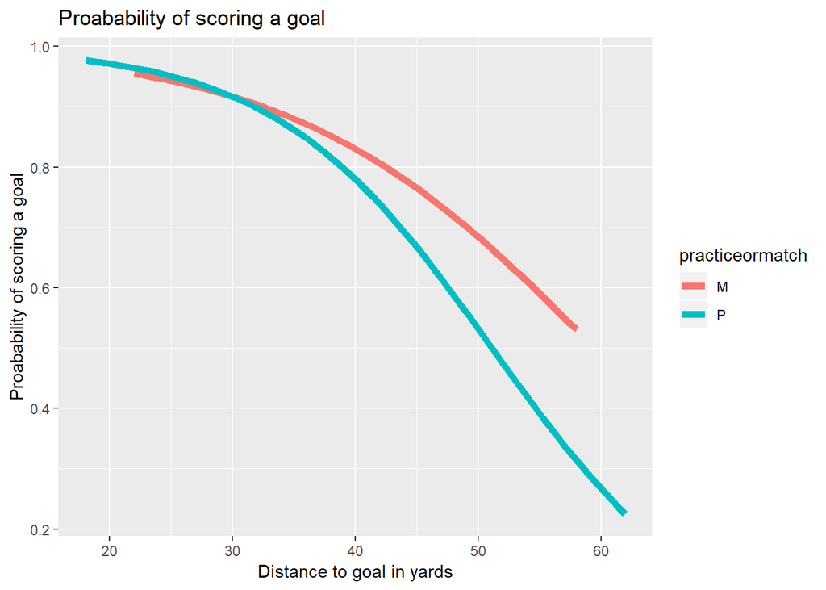

```r
# Calling the ggplot2 library
library(ggplot2)

#Using fkicks data set in ggplot function, gave x variable as yards and y variable as goal
ggplot(fkicks, aes(x=yards, y=goal, color=practiceormatch)) +

# Using stat_smooth function, used glm - binomial (logit) model
stat_smooth(method="glm", se=FALSE, method.args = list(family=binomial), size = 2) +

# Gave labels to x & y axis, also gave the title to the plot
ylab("Proabability of scoring a goal") + xlab("Distance to goal in yards") + ggtitle("Proabability of scoring a goal")
```